# Background

Using devices such as Jawbone Up, Nike FuelBand, and Fitbit it is now possible to collect a large amount of data about personal activity relatively inexpensively. These type of devices are part of the quantified self movement – a group of enthusiasts who take measurements about themselves regularly to improve their health, to find patterns in their behavior, or because they are tech geeks. One thing that people regularly do is quantify how much of a particular activity they do, but they rarely quantify how well they do it. In this project, your goal will be to use data from accelerometers on the belt, forearm, arm, and dumbell of 6 participants. They were asked to perform barbell lifts correctly and incorrectly in 5 different ways. More information is available from the website here: http://web.archive.org/web/20161224072740/http:/groupware.les.inf.puc-rio.br/har (see the section on the Weight Lifting Exercise Dataset).

```r
library(caret)
```

```r
library(ggplot2)
library(rpart)
library(rattle)
library(RColorBrewer)
library(randomForest)
library(gbm)
library(plyr)
```

```r
download.file(url = "https://d396qusza40orc.cloudfront.net/predmachlearn/pml-training.csv",
              destfile = "./pml-training.csv", method = "curl")
training_data <- read.csv("./pml-training.csv", na.strings=c("NA","#DIV/0!",""))
download.file(url = "https://d396qusza40orc.cloudfront.net/predmachlearn/pml-testing.csv",
              destfile = "./pml-testing.csv", method = "curl")
testing_data <- read.csv("./pml-testing.csv", na.strings=c("NA","#DIV/0!",""))
```

# Cleaning the data

remove all columns contain NA and remove features that are not in the testing dataset.

```r
 NA_trainingCount = sapply(1:dim(training_data)[2],function(x)sum(is.na(training_data[,x])))
    NA_traininglist = which(NA_trainingCount>0)
    training_data = training_data[,-NA_traininglist]
    training_data = training_data[,-c(1:7)]

    NA_testingCount = sapply(1:dim(testing_data)[2],function(x)sum(is.na(testing_data[,x])))
    NA_testinglist = which(NA_testingCount>0)
    testing_data = testing_data[,-NA_testinglist]
    testing_data = testing_data[,-c(1:7)]
    dim(training_data); dim(testing_data)
```

```
## [1] 19622    53
```

```
## [1] 20 53
```

# Data partition

```r
set.seed(12345)

inTrain <- createDataPartition(training_data$classe, p=0.6, list=FALSE)
training <- training_data[inTrain,]
testing <- training_data[-inTrain,]

dim(training); dim(testing)
```

```
## [1] 11776    53
```

```
## [1] 7846   53
```

# Decision Tree Model

[figure not shown]

```r
modFit_DT <- rpart(classe ~ ., data = training, method="class")
fancyRpartPlot(modFit_DT)
```

```r
set.seed(12345)

prediction1 <- predict(modFit_DT, newdata=testing, type = "class")
confusionMatrix(prediction1, testing$class)
```

```
## Confusion Matrix and Statistics
##
##           Reference
## Prediction    A    B    C    D    E
##          A 1995  246   49   83   51
##          B   75  890  111  119  115
##          C   44  198 1094  153  143
##          D   74  112   79  840   94
##          E   44   72   35   91 1039
##
## Overall Statistics
##
##                Accuracy : 0.7466
##                  95% CI : (0.7368, 0.7562)
##     No Information Rate : 0.2845
##     P-Value [Acc > NIR] : < 2.2e-16
##
##                   Kappa : 0.6787
##
##  Mcnemar's Test P-Value : < 2.2e-16
##
## Statistics by Class:
##
##                      Class: A Class: B Class: C Class: D Class: E
## Sensitivity            0.8938   0.5863   0.7997   0.6532   0.7205
## Specificity            0.9236   0.9336   0.9169   0.9453   0.9622
## Pos Pred Value         0.8230   0.6794   0.6703   0.7006   0.8111
## Neg Pred Value         0.9563   0.9039   0.9559   0.9329   0.9386
## Prevalence             0.2845   0.1935   0.1744   0.1639   0.1838
## Detection Rate         0.2543   0.1134   0.1394   0.1071   0.1324
## Detection Prevalence   0.3089   0.1670   0.2080   0.1528   0.1633
## Balanced Accuracy      0.9087   0.7600   0.8583   0.7992   0.8414
```

# Random Forest Model

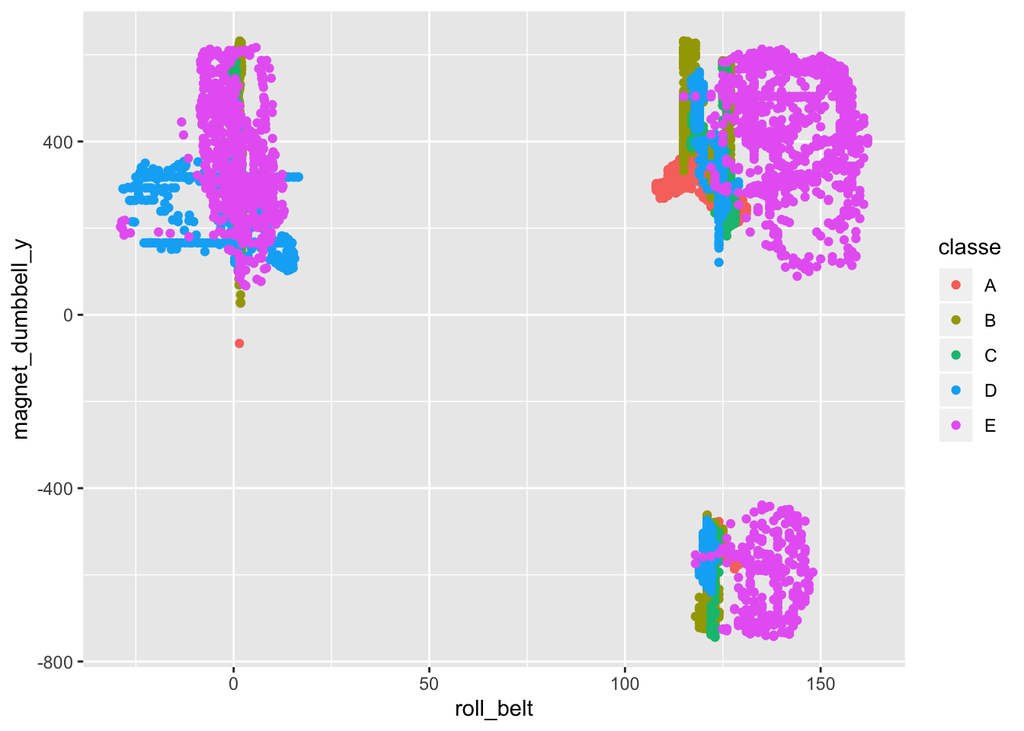

```r
modfit_RF=randomForest(classe~., data=training, method='class')
prediction2 = predict(modfit_RF,testing,type='class')
qplot(roll_belt, magnet_dumbbell_y, colour=classe, data=training)
```

```r
confusionMatrix(prediction2, testing$class)
```

```
## Confusion Matrix and Statistics
##
##           Reference
## Prediction    A    B    C    D    E
##          A 2229    5    0    0    0
##          B    3 1513    6    0    0
##          C    0    0 1357    5    2
##          D    0    0    5 1281    6
##          E    0    0    0    0 1434
##
## Overall Statistics
##
##                Accuracy : 0.9959
##                  95% CI : (0.9942, 0.9972)
##     No Information Rate : 0.2845
##     P-Value [Acc > NIR] : < 2.2e-16
##
##                   Kappa : 0.9948
##
##  Mcnemar's Test P-Value : NA
##
## Statistics by Class:
##
##                      Class: A Class: B Class: C Class: D Class: E
## Sensitivity            0.9987   0.9967   0.9920   0.9961   0.9945
## Specificity            0.9991   0.9986   0.9989   0.9983   1.0000
## Pos Pred Value         0.9978   0.9941   0.9949   0.9915   1.0000
## Neg Pred Value         0.9995   0.9992   0.9983   0.9992   0.9988
## Prevalence             0.2845   0.1935   0.1744   0.1639   0.1838
## Detection Rate         0.2841   0.1928   0.1730   0.1633   0.1828
## Detection Prevalence   0.2847   0.1940   0.1738   0.1647   0.1828
## Balanced Accuracy      0.9989   0.9976   0.9954   0.9972   0.9972
```

# Conclusion

Decision tree model is about 75% accuracy while random forest model has 99% accuracy.